# Rasheed Hameed

*Assignment 1*

```python
#Loading libraries

import numpy as np
import pandas as pd
import matplotlib.pyplot as plt
%matplotlib inline
```

```python
#Checking path where the data is located
%pwd
```

```
'C:\\Users\\rhame\\OneDrive\\class\\Programming Machine Learning Applications\\Assignment 1'
```

**1. Explore the general characteristics of the data as a whole: examine the means, standard deviations, and other statistics associated with the numerical attributes; show the distributions of values associated with categorical attributes; etc.**

```python
#Read the data into panda's dataframe
bankdata_df = pd.read_csv("C:/Users/rhame/OneDrive/class/Programming Machine Learning Applications/Assignment 1/bank_data.csv", sep =',')
bankdata_df.head(5)
```

|  | id | age | income | children | gender | region | married | car | savings_acct | current_acct | mortgage | pep |
| --- | --- | --- | --- | --- | --- | --- | --- | --- | --- | --- | --- | --- |
| 0 | ID12101 | 48 | 17546.0 | 1 | FEMALE | INNER_CITY | NO | NO | NO | NO | NO | YES |
| 1 | ID12102 | 40 | 30085.1 | 3 | MALE | TOWN | YES | YES | NO | YES | YES | NO |
| 2 | ID12103 | 51 | 16575.4 | 0 | FEMALE | INNER_CITY | YES | YES | YES | YES | NO | NO |
| 3 | ID12104 | 23 | 20375.4 | 3 | FEMALE | TOWN | YES | NO | NO | YES | NO | NO |
| 4 | ID12105 | 57 | 50576.3 | 0 | FEMALE | RURAL | YES | NO | YES | NO | NO | NO |

```python
#Looking at the header or column names
bankdata_df.columns
```

```
Index(['id', 'age', 'income', 'children', 'gender', 'region', 'married', 'car',
       'savings_acct', 'current_acct', 'mortgage', 'pep'],
      dtype='object')
```

```python
#Another way to see some values in the dataframe
bankdata_df.values
```

```
array([['ID12101', 48, 17546.0, ..., 'NO', 'NO', 'YES'],
       ['ID12102', 40, 30085.1, ..., 'YES', 'YES', 'NO'],
       ['ID12103', 51, 16575.4, ..., 'YES', 'NO', 'NO'],
       ...,
       ['ID12698', 31, 15976.3, ..., 'NO', 'NO', 'YES'],
       ['ID12699', 29, 14711.8, ..., 'NO', 'YES', 'NO'],
       ['ID12700', 38, 26671.6, ..., 'YES', 'YES', 'YES']], dtype=object)
```

```python
#Explorer the datatypes of the columns
bankdata_df.dtypes
```

```
id               object
age               int64
income          float64
children          int64
gender           object
region           object
married          object
car              object
savings_acct     object
current_acct     object
mortgage         object
pep              object
dtype: object
```

**2. Explore the general characteristics of the data as a whole: examine the means, standard deviations, and other statistics associated with the numerical attributes; show the distributions of values associated with categorical attributes; etc.**

```python
#brute force of knowing the general charactersitics of the different columns including the - like count, mean, frequency,
bankdata_df.describe(include="all")
```

|  | id | age | income | children | gender | region | married | car | savings_acct | current_acct | mortgage | pep |
| --- | --- | --- | --- | --- | --- | --- | --- | --- | --- | --- | --- | --- |
| count | 600 | 600.000000 | 600.000000 | 600.000000 | 600 | 600 | 600 | 600 | 600 | 600 | 600 | 600 |
| unique | 600 | NaN | NaN | NaN | 2 | 4 | 2 | 2 | 2 | 2 | 2 | 2 |
| top | ID12240 | NaN | NaN | NaN | FEMALE | INNER_CITY | YES | NO | YES | YES | NO | NO |
| freq | 1 | NaN | NaN | NaN | 300 | 269 | 396 | 304 | 414 | 455 | 391 | 326 |
| mean | NaN | 42.395000 | 27524.031217 | 1.011667 | NaN | NaN | NaN | NaN | NaN | NaN | NaN | NaN |
| std | NaN | 14.424947 | 12899.468246 | 1.056752 | NaN | NaN | NaN | NaN | NaN | NaN | NaN | NaN |
| min | NaN | 18.000000 | 5014.210000 | 0.000000 | NaN | NaN | NaN | NaN | NaN | NaN | NaN | NaN |
| 25% | NaN | 30.000000 | 17264.500000 | 0.000000 | NaN | NaN | NaN | NaN | NaN | NaN | NaN | NaN |
| 50% | NaN | 42.000000 | 24925.300000 | 1.000000 | NaN | NaN | NaN | NaN | NaN | NaN | NaN | NaN |
| 75% | NaN | 55.250000 | 36172.675000 | 2.000000 | NaN | NaN | NaN | NaN | NaN | NaN | NaN | NaN |
| max | NaN | 67.000000 | 63130.100000 | 3.000000 | NaN | NaN | NaN | NaN | NaN | NaN | NaN | NaN |

```python
#descriptive statistics of numerical data of the pandas dataframe
bankdata_df.describe()
```

|  | age | income | children |
| --- | --- | --- | --- |
| count | 600.000000 | 600.000000 | 600.000000 |
| mean | 42.395000 | 27524.031217 | 1.011667 |
| std | 14.424947 | 12899.468246 | 1.056752 |
| min | 18.000000 | 5014.210000 | 0.000000 |
| 25% | 30.000000 | 17264.500000 | 0.000000 |
| 50% | 42.000000 | 24925.300000 | 1.000000 |
| 75% | 55.250000 | 36172.675000 | 2.000000 |
| max | 67.000000 | 63130.100000 | 3.000000 |

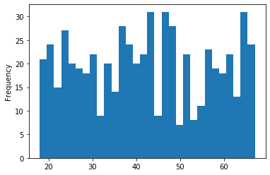

```python
bankdata_df["age"].plot(kind="hist", bins=30)
```

*The age ranges from 18 to 65+. The distribution seems sparse*

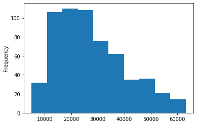

```python
bankdata_df["income"].plot(kind="hist", bins=10)
```

*The income distribution shows around the modal is around 18K to 29K*

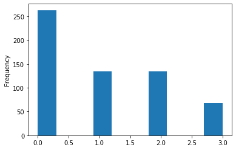

```python
bankdata_df["children"].plot(kind="hist", bins=10)
```

**Exploring data both categorical values using bar plot**

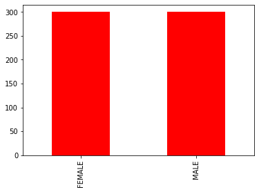

```python
bankdata_df['gender'].value_counts().plot(kind='bar', color='red')
```

*looks like male and females are well balance within this dataset*

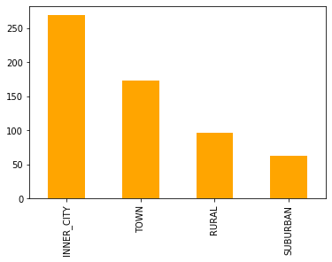

```python
bankdata_df['region'].value_counts().plot(kind='bar', color = 'orange')
```

*the regions show that majority are from inner_city and the least are from suburbs*

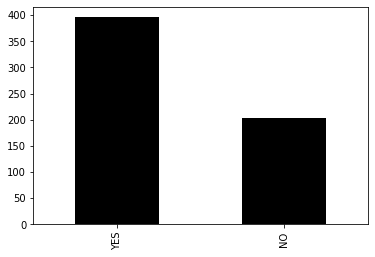

```python
bankdata_df['married'].value_counts().plot(kind='bar', color='black')
```

*Out of 600 near to 400 are married and 200 are unmarried*

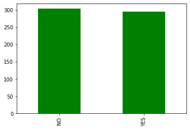

```python
bankdata_df['car'].value_counts().plot(kind='bar', color='green')
```

*This looks like almost of the the dataset own cars and half do not*

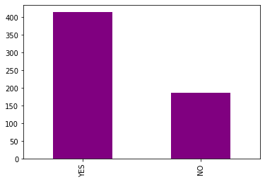

```python
bankdata_df['savings_acct'].value_counts().plot(kind='bar', color='purple')
```

*Majority of the data set population own savings account and about 200 do not have saving accounts*

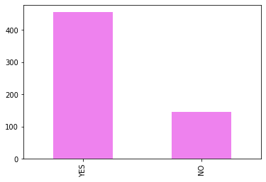

```python
bankdata_df['current_acct'].value_counts().plot(kind='bar', color='violet')
```

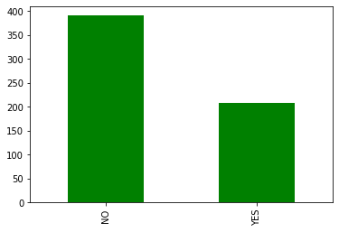

```python
bankdata_df['mortgage'].value_counts().plot(kind='bar', color='green')
```

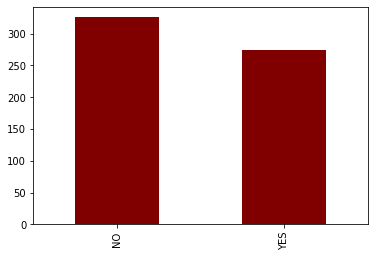

```python
bankdata_df['pep'].value_counts().plot(kind='bar', color ='maroon')
```

*We can see that some 300+ customer do not have Personal Equity Plan and will need to be targeted for this campaign*

**2. Suppose that the hypothetical bank is particularly interested in customers who buy the PEP (Personal Equity Plan) product. Compare and contrast the subsets of customers who buy and don't buy the PEP. Compute summaries (as in part 1) of the selected data with respect to all other attributes. Can you observe any significant differences between these segments of customers? Discuss your observations.**

```python
#Trying to see how the pep is compared to some of the numerical fields like age, income and children
bankdata_df.groupby("pep").describe()
```

| pep | age count | age mean | age std | age min | age 25% | age 50% | age 75% | age max | income count | income mean | income ... | income 75% | income max | children count | children mean | children std | children min | children 25% | children 50% | children 75% | children max |
| --- | --- | --- | --- | --- | --- | --- | --- | --- | --- | --- | --- | --- | --- | --- | --- | --- | --- | --- | --- | --- | --- |
| NO | 326.0 | 40.098160 | 14.123506 | 18.0 | 27.0 | 40.0 | 51.0 | 67.0 | 326.0 | 24900.953374 | ... | 31210.90 | 61554.6 | 326.0 | 1.067485 | 1.195524 | 0.0 | 0.0 | 0.0 | 2.0 | 3.0 |
| YES | 274.0 | 45.127737 | 14.327991 | 18.0 | 34.0 | 45.0 | 58.0 | 67.0 | 274.0 | 30644.919453 | ... | 38458.35 | 63130.1 | 274.0 | 0.945255 | 0.860571 | 0.0 | 0.0 | 1.0 | 1.0 | 3.0 |

2 rows × 24 columns

*The description about does not provide a clear picture and more different techniques are needed to match with other attributes*

```python
gg = pd.crosstab(bankdata_df["pep"], bankdata_df["age"])
gg
```

| age pep | 18 | 19 | 20 | 21 | 22 | 23 | 24 | 25 | 26 | 27 | ... | 58 | 59 | 60 | 61 | 62 | 63 | 64 | 65 | 66 | 67 |
| --- | --- | --- | --- | --- | --- | --- | --- | --- | --- | --- | --- | --- | --- | --- | --- | --- | --- | --- | --- | --- | --- |
| NO | 9 | 6 | 11 | 5 | 10 | 11 | 5 | 7 | 7 | 12 | ... | 8 | 2 | 3 | 6 | 2 | 6 | 7 | 7 | 4 | 4 |
| YES | 2 | 4 | 5 | 3 | 5 | 6 | 5 | 3 | 3 | 7 | ... | 11 | 8 | 5 | 8 | 6 | 7 | 13 | 4 | 6 | 10 |

2 rows × 50 columns

*In the above limited view we can see that some of the older ages have higher yes values*

```python
# Seperating the dataframe with that pep and nonpep
PepCustomers = bankdata_df[(bankdata_df.pep=='YES')]
NonPepCustomers = bankdata_df[(bankdata_df.pep=='NO')]
```

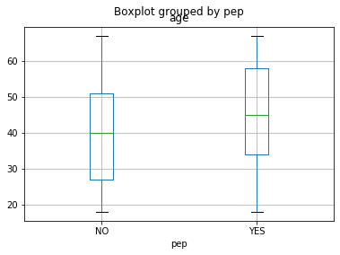

```python
bankdata_df.boxplot(by = "pep", column = ['age'])
```

*The above plot gives a good view of how the distribution of PEP customers are age wise. We can see the IQR is higher for pep customers for age. The customer tend to be older that sign up for Personal Equity Plan. The median for this is around age 45 and for the median for customers that don't have it is around 40.*

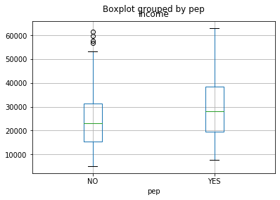

```python
bankdata_df.boxplot(by = "pep", column = ['income'])
```

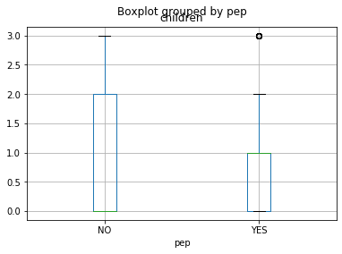

```python
bankdata_df.boxplot(by = "pep", column = ['children'])
```

```python
gg = pd.crosstab(bankdata_df["pep"], bankdata_df["gender"])
gg
```

| gender pep | FEMALE | MALE |
| --- | --- | --- |
| NO | 170 | 156 |
| YES | 130 | 144 |

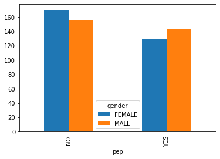

```python
plt.show(gg.plot(kind="bar"))
```

*About 130 females customers are signed up for pep and 144 for male*

```python
gg = pd.crosstab(bankdata_df["pep"], bankdata_df["region"])
gg
```

| region pep | INNER_CITY | RURAL | SUBURBAN | TOWN |
| --- | --- | --- | --- | --- |
| NO | 146 | 50 | 28 | 102 |
| YES | 123 | 46 | 34 | 71 |

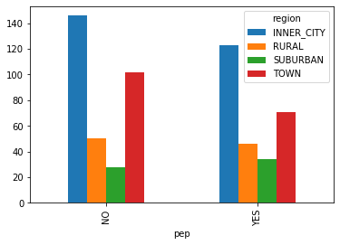

```python
plt.show(gg.plot(kind="bar"))
```

*Majority of the customers are from inner city that opt in for pep. The plot also shows that majority of the customers from the bank are from inner city area.*

```python
gg = pd.crosstab(bankdata_df["pep"], bankdata_df["married"])
gg
```

| married pep | NO | YES |
| --- | --- | --- |
| NO | 84 | 242 |
| YES | 120 | 154 |

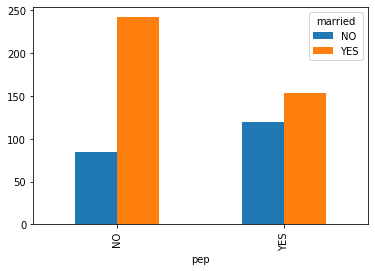

```python
plt.show(gg.plot(kind="bar"))
```

*154 of married customers are selecting pep and 242 of married customers are selecting no for pep*

```python
gg = pd.crosstab(bankdata_df["pep"], bankdata_df["car"])
gg
```

| car pep | NO | YES |
| --- | --- | --- |
| NO | 168 | 158 |
| YES | 136 | 138 |

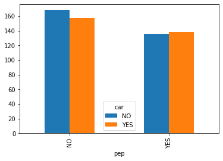

```python
plt.show(gg.plot(kind="bar"))
```

*this looks like it is pretty balance of yes and no and customers selecting pep and not. About 138 customers had cars and opt in for pep*

```python
gg = pd.crosstab(bankdata_df["pep"], bankdata_df["savings_acct"])
gg
```

| savings_acct pep | NO | YES |
| --- | --- | --- |
| NO | 91 | 235 |
| YES | 95 | 179 |

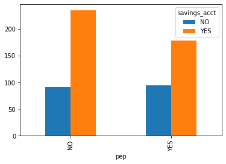

```python
plt.show(gg.plot(kind="bar"))
```

```python
gg = pd.crosstab(bankdata_df["pep"], bankdata_df["current_acct"])
gg
```

| current_acct pep | NO | YES |
| --- | --- | --- |
| NO | 82 | 244 |
| YES | 63 | 211 |

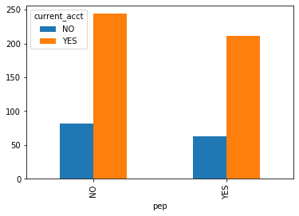

```python
plt.show(gg.plot(kind="bar"))
```

*About 211 customers have pep and current accounts and 244 don't*

```python
gg = pd.crosstab(bankdata_df["pep"], bankdata_df["mortgage"])
gg
```

| mortgage pep | NO | YES |
| --- | --- | --- |
| NO | 209 | 117 |
| YES | 182 | 92 |

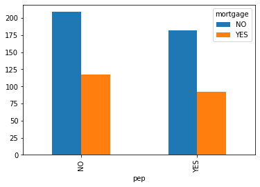

```python
plt.show(gg.plot(kind="bar"))
```

*the pep customers are pretty balance with mortage or not having mortgage. Those who have a mortgage(92) have pep and the ones who do not have mortage 182 have pep*

**3. Use z-score normalization to standardize the values of the income attribute. [Do not change the original income attribute in the table.]**

```python
income_z = (bankdata_df["income"] - bankdata_df["income"].mean()) / bankdata_df["income"].std()
income_z.head(10)
```

```
0   -0.773523
1    0.198541
2   -0.848766
3   -0.554180
4    1.787071
5    0.802015
6   -1.445560
7   -0.199809
8   -0.172079
9   -0.256749
Name: income, dtype: float64
```

```python
bankdata_df["income_z"]=income_z
bankdata_df.head()
```

|  | id | age | income | children | gender | region | married | car | savings_acct | current_acct | mortgage | pep | income_z |
| --- | --- | --- | --- | --- | --- | --- | --- | --- | --- | --- | --- | --- | --- |
| 0 | ID12101 | 48 | 17546.0 | 1 | FEMALE | INNER_CITY | NO | NO | NO | NO | NO | YES | -0.773523 |
| 1 | ID12102 | 40 | 30085.1 | 3 | MALE | TOWN | YES | YES | NO | YES | YES | NO | 0.198541 |
| 2 | ID12103 | 51 | 16575.4 | 0 | FEMALE | INNER_CITY | YES | YES | YES | YES | NO | NO | -0.848766 |
| 3 | ID12104 | 23 | 20375.4 | 3 | FEMALE | TOWN | YES | NO | NO | YES | NO | NO | -0.554180 |
| 4 | ID12105 | 57 | 50576.3 | 0 | FEMALE | RURAL | YES | NO | YES | NO | NO | NO | 1.787071 |

**4. Discretize the age attribute into 3 categories (corresponding to "young", "mid-age", and "old"). [Do not change the original age attribute in the table.]**

```python
age_bins = pd.qcut(bankdata_df.age, 3)
age_bins.head(10)
```

```
0      (35.0, 49.0]
1      (35.0, 49.0]
2      (49.0, 67.0]
3    (17.999, 35.0]
4      (49.0, 67.0]
5      (49.0, 67.0]
6    (17.999, 35.0]
7      (49.0, 67.0]
8      (35.0, 49.0]
9      (49.0, 67.0]
Name: age, dtype: category
Categories (3, interval[float64]): [(17.999, 35.0] < (35.0, 49.0] < (49.0, 67.0]]
```

```python
age_bins = pd.qcut(bankdata_df.age, [0, .33, .66, 1], labels=["young", "mid-age", "old"])
age_bins.head(10)
```

```
0    mid-age
1    mid-age
2        old
3      young
4        old
5        old
6      young
7        old
8    mid-age
9        old
Name: age, dtype: category
Categories (3, object): [young < mid-age < old]
```

**5. Use Min-Max Normalization to transform the values of all numeric attributes (income, age, children) in the original table (before the transformations in parts 3 and 4 above) onto the range 0.0-1.0.**

$$v' = \frac{v-min_a}{max_a -min_a}(new_{max_a} - new_{min_a}) + new_{min_a}$$

```python
#min-max normalization for income
minmax_income_norm_df=((bankdata_df['income']-bankdata_df['income'].min())/(bankdata_df['income'].max()-bankdata_df['income'].min()))
minmax_income_norm_df.head(10)
```

```
0    0.215634
1    0.431395
2    0.198933
3    0.264320
4    0.783987
5    0.565343
6    0.066468
7    0.342977
8    0.349132
9    0.330338
Name: income, dtype: float64
```

```python
#min-max normalization for age
minmax_age_norm_df=(bankdata_df['age']-bankdata_df['age'].min())/(bankdata_df['age'].max()-bankdata_df['age'].min())
minmax_age_norm_df.head(10)
```

```
0    0.612245
1    0.448980
2    0.673469
3    0.102041
4    0.795918
5    0.795918
6    0.081633
7    0.816327
8    0.387755
9    0.734694
Name: age, dtype: float64
```

```python
#min-max normalization for children
minmax_children_norm_df=(bankdata_df['children']-bankdata_df['children'].min())/(bankdata_df['children'].max()-bankdata_df['children'].min())
minmax_children_norm_df.head(10)
```

```
0    0.333333
1    1.000000
2    0.000000
3    1.000000
4    0.000000
5    0.666667
6    0.000000
7    0.000000
8    0.666667
9    0.666667
Name: children, dtype: float64
```

**6.Convert the table (after normalization in part 5) into the standard spreadsheet format. Note that this requires converting each categorical attribute into multiple binary ("dummy") attributes (one for each values of the categorical attribute) and assigning binary values corresponding to the presence or not presence of the attribute value in the original record). The numeric attributes should remain unchanged. Save this new table into a file called bank_numeric.csv and submit it along with your assignment. [Hint: you might consider using the get_dummies for Pandas data frames.]**

```python
#'gender', 'region', 'married', 'car', 'savings_acct', 'current_acct', 'mortgage', 'pep
bank_numeric =  pd.get_dummies(data=bankdata_df, columns=['gender','region','married','car','married', 'car', 'savings_acct', 'current_acct', 'mortgage', 'pep'])
bank_numeric.head(10)
```

|  | id | age | income | children | income_z | gender_FEMALE | gender_MALE | region_INNER_CITY | region_RURAL | region_SUBURBAN | ... | car_NO | car_YES | savings_acct_NO | savings_acct_YES | current_acct_NO | current_acct_YES | mortgage_NO | mortgage_YES | pep_NO | pep_YES |
| --- | --- | --- | --- | --- | --- | --- | --- | --- | --- | --- | --- | --- | --- | --- | --- | --- | --- | --- | --- | --- | --- |
| 0 | ID12101 | 48 | 17546.00 | 1 | -0.773523 | 1 | 0 | 1 | 0 | 0 | ... | 1 | 0 | 1 | 0 | 1 | 0 | 1 | 0 | 0 | 1 |
| 1 | ID12102 | 40 | 30085.10 | 3 | 0.198541 | 0 | 1 | 0 | 0 | 0 | ... | 0 | 1 | 1 | 0 | 0 | 1 | 0 | 1 | 1 | 0 |
| 2 | ID12103 | 51 | 16575.40 | 0 | -0.848766 | 1 | 0 | 1 | 0 | 0 | ... | 0 | 1 | 0 | 1 | 0 | 1 | 1 | 0 | 1 | 0 |
| 3 | ID12104 | 23 | 20375.40 | 3 | -0.554180 | 1 | 0 | 0 | 0 | 0 | ... | 1 | 0 | 1 | 0 | 0 | 1 | 1 | 0 | 1 | 0 |
| 4 | ID12105 | 57 | 50576.30 | 0 | 1.787071 | 1 | 0 | 0 | 1 | 0 | ... | 1 | 0 | 0 | 1 | 1 | 0 | 1 | 0 | 1 | 0 |
| 5 | ID12106 | 57 | 37869.60 | 2 | 0.802015 | 1 | 0 | 0 | 0 | 0 | ... | 1 | 0 | 0 | 1 | 0 | 1 | 1 | 0 | 0 | 1 |
| 6 | ID12107 | 22 | 8877.07 | 0 | -1.445560 | 0 | 1 | 0 | 1 | 0 | ... | 1 | 0 | 1 | 0 | 0 | 1 | 1 | 0 | 0 | 1 |
| 7 | ID12108 | 58 | 24946.60 | 0 | -0.199809 | 0 | 1 | 0 | 0 | 0 | ... | 0 | 1 | 0 | 1 | 0 | 1 | 1 | 0 | 1 | 0 |
| 8 | ID12109 | 37 | 25304.30 | 2 | -0.172079 | 1 | 0 | 0 | 0 | 1 | ... | 0 | 1 | 1 | 0 | 1 | 0 | 1 | 0 | 1 | 0 |
| 9 | ID12110 | 54 | 24212.10 | 2 | -0.256749 | 0 | 1 | 0 | 0 | 0 | ... | 0 | 1 | 0 | 1 | 0 | 1 | 1 | 0 | 1 | 0 |

10 rows × 27 columns

```python
bank_numeric.to_csv("bank_numeric.csv", float_format="%1.2f") #saving the file
```

**7. Using the standardized data set (of the previous part), perform basic correlation analysis among the attributes. Discuss your results by indicating any significant positive or negative correlations among pairs of attributes. You need to construct a complete Correlation Matrix. Be sure to first remove the Customer ID column before creating the correlation matrix. [Hint: you can create the correlation matrix by using the corr() function in Pandas, try at least two corr methods and compare them].**

```python
#removing the id column
del bank_numeric['id']
```

```python
bank_numeric.corr(method='pearson')
```

|  | age | income | children | income_z | gender_FEMALE | gender_MALE | region_INNER_CITY | region_RURAL | region_SUBURBAN | region_TOWN | ... | car_NO | car_YES | savings_acct_NO | savings_acct_YES | current_acct_NO | current_acct_YES | mortgage_NO | mortgage_YES | pep_NO | pep_YES |
| --- | --- | --- | --- | --- | --- | --- | --- | --- | --- | --- | --- | --- | --- | --- | --- | --- | --- | --- | --- | --- | --- |
| age | 1.000000 | 0.752726 | 0.023572 | 0.752726 | 0.090081 | -0.090081 | -0.025171 | 0.018635 | 0.031345 | -0.008510 | ... | -0.077733 | 0.077733 | -0.184389 | 0.184389 | 0.035312 | -0.035312 | 0.016154 | -0.016154 | -0.173825 | 0.173825 |
| income | 0.752726 | 1.000000 | 0.036761 | 1.000000 | 0.023845 | -0.023845 | -0.047564 | 0.084776 | 0.029824 | -0.036431 | ... | -0.081556 | 0.081556 | -0.266164 | 0.266164 | -0.031616 | 0.031616 | 0.014662 | -0.014662 | -0.221991 | 0.221991 |
| children | 0.023572 | 0.036761 | 1.000000 | 0.036761 | 0.014206 | -0.014206 | -0.051222 | 0.089902 | -0.014122 | -0.007033 | ... | -0.036455 | 0.036455 | -0.041536 | 0.041536 | -0.006238 | 0.006238 | 0.074339 | -0.074339 | 0.057663 | -0.057663 |
| income_z | 0.752726 | 1.000000 | 0.036761 | 1.000000 | 0.023845 | -0.023845 | -0.047564 | 0.084776 | 0.029824 | -0.036431 | ... | -0.081556 | 0.081556 | -0.266164 | 0.266164 | -0.031616 | 0.031616 | 0.014662 | -0.014662 | -0.221991 | 0.221991 |
| gender_FEMALE | 0.090081 | 0.023845 | 0.014206 | 0.023845 | 1.000000 | -1.000000 | -0.023459 | -0.009092 | -0.010951 | 0.040472 | ... | 0.006667 | -0.006667 | 0.007207 | -0.007207 | -0.019466 | 0.019466 | 0.066465 | -0.066465 | 0.046843 | -0.046843 |
| gender_MALE | -0.090081 | -0.023845 | -0.014206 | -0.023845 | -1.000000 | 1.000000 | 0.023459 | 0.009092 | 0.010951 | -0.040472 | ... | -0.006667 | 0.006667 | -0.007207 | 0.007207 | 0.019466 | -0.019466 | -0.066465 | 0.066465 | -0.046843 | 0.046843 |
| region_INNER_CITY | -0.025171 | -0.047564 | -0.051222 | -0.047564 | -0.023459 | 0.023459 | 1.000000 | -0.393444 | -0.306032 | -0.573814 | ... | 0.018143 | -0.018143 | 0.091373 | -0.091373 | -0.007894 | 0.007894 | -0.002098 | 0.002098 | -0.001054 | 0.001054 |
| region_RURAL | 0.018635 | 0.084776 | 0.089902 | 0.084776 | -0.009092 | 0.009092 | -0.393444 | 1.000000 | -0.148158 | -0.277798 | ... | -0.024006 | 0.024006 | -0.036960 | 0.036960 | 0.008496 | -0.008496 | 0.051908 | -0.051908 | -0.019714 | 0.019714 |
| region_SUBURBAN | 0.031345 | 0.029824 | -0.014122 | 0.029824 | -0.010951 | 0.010951 | -0.306032 | -0.148158 | 1.000000 | -0.216080 | ... | 0.061184 | -0.061184 | -0.002605 | 0.002605 | -0.038157 | 0.038157 | -0.004635 | 0.004635 | -0.062508 | 0.062508 |
| region_TOWN | -0.008510 | -0.036431 | -0.007033 | -0.036431 | 0.040472 | -0.040472 | -0.573814 | -0.277798 | -0.216080 | 1.000000 | ... | -0.041604 | 0.041604 | -0.068654 | 0.068654 | 0.027431 | -0.027431 | -0.036591 | 0.036591 | 0.059115 | -0.059115 |
| married_NO | -0.010394 | 0.008386 | 0.048716 | 0.008386 | 0.021110 | -0.021110 | -0.003254 | 0.022649 | -0.012483 | -0.006369 | ... | -0.009571 | 0.009571 | 0.028604 | -0.028604 | -0.059996 | 0.059996 | -0.021711 | 0.021711 | -0.189578 | 0.189578 |
| married_YES | 0.010394 | -0.008386 | -0.048716 | -0.008386 | -0.021110 | 0.021110 | 0.003254 | -0.022649 | 0.012483 | 0.006369 | ... | 0.009571 | -0.009571 | -0.028604 | 0.028604 | 0.059996 | -0.059996 | 0.021711 | -0.021711 | 0.189578 | -0.189578 |
| car_NO | -0.077733 | -0.081556 | -0.036455 | -0.081556 | 0.006667 | -0.006667 | 0.018143 | -0.024006 | 0.061184 | -0.041604 | ... | 1.000000 | -1.000000 | 0.034310 | -0.034310 | -0.034783 | 0.034783 | -0.007743 | 0.007743 | 0.018917 | -0.018917 |
| car_YES | 0.077733 | 0.081556 | 0.036455 | 0.081556 | -0.006667 | 0.006667 | -0.018143 | 0.024006 | -0.061184 | 0.041604 | ... | -1.000000 | 1.000000 | -0.034310 | 0.034310 | 0.034783 | -0.034783 | 0.007743 | -0.007743 | -0.018917 | 0.018917 |
| married_NO | -0.010394 | 0.008386 | 0.048716 | 0.008386 | 0.021110 | -0.021110 | -0.003254 | 0.022649 | -0.012483 | -0.006369 | ... | -0.009571 | 0.009571 | 0.028604 | -0.028604 | -0.059996 | 0.059996 | -0.021711 | 0.021711 | -0.189578 | 0.189578 |
| married_YES | 0.010394 | -0.008386 | -0.048716 | -0.008386 | -0.021110 | 0.021110 | 0.003254 | -0.022649 | 0.012483 | 0.006369 | ... | 0.009571 | -0.009571 | -0.028604 | 0.028604 | 0.059996 | -0.059996 | 0.021711 | -0.021711 | 0.189578 | -0.189578 |
| car_NO | -0.077733 | -0.081556 | -0.036455 | -0.081556 | 0.006667 | -0.006667 | 0.018143 | -0.024006 | 0.061184 | -0.041604 | ... | 1.000000 | -1.000000 | 0.034310 | -0.034310 | -0.034783 | 0.034783 | -0.007743 | 0.007743 | 0.018917 | -0.018917 |
| car_YES | 0.077733 | 0.081556 | 0.036455 | 0.081556 | -0.006667 | 0.006667 | -0.018143 | 0.024006 | -0.061184 | 0.041604 | ... | -1.000000 | 1.000000 | -0.034310 | 0.034310 | 0.034783 | -0.034783 | 0.007743 | -0.007743 | -0.018917 | 0.018917 |
| savings_acct_NO | -0.184389 | -0.266164 | -0.041536 | -0.266164 | 0.007207 | -0.007207 | 0.091373 | -0.036960 | -0.002605 | -0.068654 | ... | 0.034310 | -0.034310 | 1.000000 | -1.000000 | 0.042511 | -0.042511 | -0.001588 | 0.001588 | -0.072779 | 0.072779 |
| savings_acct_YES | 0.184389 | 0.266164 | 0.041536 | 0.266164 | -0.007207 | 0.007207 | -0.091373 | 0.036960 | 0.002605 | 0.068654 | ... | -0.034310 | 0.034310 | -1.000000 | 1.000000 | -0.042511 | 0.042511 | 0.001588 | -0.001588 | 0.072779 | -0.072779 |
| current_acct_NO | 0.035312 | -0.031616 | -0.006238 | -0.031616 | -0.019466 | 0.019466 | -0.007894 | 0.008496 | -0.038157 | 0.027431 | ... | -0.034783 | 0.034783 | 0.042511 | -0.042511 | 1.000000 | -1.000000 | -0.036704 | 0.036704 | 0.025141 | -0.025141 |
| current_acct_YES | -0.035312 | 0.031616 | 0.006238 | 0.031616 | 0.019466 | -0.019466 | 0.007894 | -0.008496 | 0.038157 | -0.027431 | ... | 0.034783 | -0.034783 | -0.042511 | 0.042511 | -1.000000 | 1.000000 | 0.036704 | -0.036704 | -0.025141 | 0.025141 |
| mortgage_NO | 0.016154 | 0.014662 | 0.074339 | 0.014662 | 0.066465 | -0.066465 | -0.002098 | 0.051908 | -0.004635 | -0.036591 | ... | -0.007743 | 0.007743 | -0.001588 | 0.001588 | -0.036704 | 0.036704 | 1.000000 | -1.000000 | -0.024182 | 0.024182 |
| mortgage_YES | -0.016154 | -0.014662 | -0.074339 | -0.014662 | -0.066465 | 0.066465 | 0.002098 | -0.051908 | 0.004635 | 0.036591 | ... | 0.007743 | -0.007743 | 0.001588 | -0.001588 | 0.036704 | -0.036704 | -1.000000 | 1.000000 | 0.024182 | -0.024182 |
| pep_NO | -0.173825 | -0.221991 | 0.057663 | -0.221991 | 0.046843 | -0.046843 | -0.001054 | -0.019714 | -0.062508 | 0.059115 | ... | 0.018917 | -0.018917 | -0.072779 | 0.072779 | 0.025141 | -0.025141 | -0.024182 | 0.024182 | 1.000000 | -1.000000 |
| pep_YES | 0.173825 | 0.221991 | -0.057663 | 0.221991 | -0.046843 | 0.046843 | 0.001054 | 0.019714 | 0.062508 | -0.059115 | ... | -0.018917 | 0.018917 | 0.072779 | -0.072779 | -0.025141 | 0.025141 | 0.024182 | -0.024182 | -1.000000 | 1.000000 |

26 rows × 26 columns

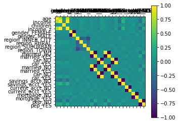

```python
plt.matshow(bank_numeric.corr())
plt.xticks(range(len(bank_numeric.columns)), bank_numeric.columns)
plt.yticks(range(len(bank_numeric.columns)), bank_numeric.columns)
plt.colorbar()
plt.show()
```

*Income and age are significantly positvely correlated. The higher the income the higher the age or vice versa. Other correlation that is noticable are the regions with each other but not significant as the prior*

```python
#different correlation method to see if there is a difference between pearson and spearman.
bank_numeric.corr(method='spearman')
```

|  | age | income | children | income_z | gender_FEMALE | gender_MALE | region_INNER_CITY | region_RURAL | region_SUBURBAN | region_TOWN | ... | car_NO | car_YES | savings_acct_NO | savings_acct_YES | current_acct_NO | current_acct_YES | mortgage_NO | mortgage_YES | pep_NO | pep_YES |
| --- | --- | --- | --- | --- | --- | --- | --- | --- | --- | --- | --- | --- | --- | --- | --- | --- | --- | --- | --- | --- | --- |
| age | 1.000000 | 0.758911 | 0.024964 | 0.758911 | 0.090110 | -0.090110 | -0.025595 | 0.019310 | 0.033328 | -0.009923 | ... | -0.076410 | 0.076410 | -0.185386 | 0.185386 | 0.033737 | -0.033737 | 0.019121 | -0.019121 | -0.173045 | 0.173045 |
| income | 0.758911 | 1.000000 | 0.028714 | 1.000000 | 0.023729 | -0.023729 | -0.056053 | 0.079373 | 0.021844 | -0.017376 | ... | -0.098120 | 0.098120 | -0.230850 | 0.230850 | -0.017240 | 0.017240 | -0.000707 | 0.000707 | -0.211201 | 0.211201 |
| children | 0.024964 | 0.028714 | 1.000000 | 0.028714 | 0.008946 | -0.008946 | -0.044789 | 0.080534 | -0.013926 | -0.006647 | ... | -0.038897 | 0.038897 | -0.047357 | 0.047357 | -0.006546 | 0.006546 | 0.072095 | -0.072095 | 0.005891 | -0.005891 |
| income_z | 0.758911 | 1.000000 | 0.028714 | 1.000000 | 0.023729 | -0.023729 | -0.056053 | 0.079373 | 0.021844 | -0.017376 | ... | -0.098120 | 0.098120 | -0.230850 | 0.230850 | -0.017240 | 0.017240 | -0.000707 | 0.000707 | -0.211201 | 0.211201 |
| gender_FEMALE | 0.090110 | 0.023729 | 0.008946 | 0.023729 | 1.000000 | -1.000000 | -0.023459 | -0.009092 | -0.010951 | 0.040472 | ... | 0.006667 | -0.006667 | 0.007207 | -0.007207 | -0.019466 | 0.019466 | 0.066465 | -0.066465 | 0.046843 | -0.046843 |
| gender_MALE | -0.090110 | -0.023729 | -0.008946 | -0.023729 | -1.000000 | 1.000000 | 0.023459 | 0.009092 | 0.010951 | -0.040472 | ... | -0.006667 | 0.006667 | -0.007207 | 0.007207 | 0.019466 | -0.019466 | -0.066465 | 0.066465 | -0.046843 | 0.046843 |
| region_INNER_CITY | -0.025595 | -0.056053 | -0.044789 | -0.056053 | -0.023459 | 0.023459 | 1.000000 | -0.393444 | -0.306032 | -0.573814 | ... | 0.018143 | -0.018143 | 0.091373 | -0.091373 | -0.007894 | 0.007894 | -0.002098 | 0.002098 | -0.001054 | 0.001054 |
| region_RURAL | 0.019310 | 0.079373 | 0.080534 | 0.079373 | -0.009092 | 0.009092 | -0.393444 | 1.000000 | -0.148158 | -0.277798 | ... | -0.024006 | 0.024006 | -0.036960 | 0.036960 | 0.008496 | -0.008496 | 0.051908 | -0.051908 | -0.019714 | 0.019714 |
| region_SUBURBAN | 0.033328 | 0.021844 | -0.013926 | 0.021844 | -0.010951 | 0.010951 | -0.306032 | -0.148158 | 1.000000 | -0.216080 | ... | 0.061184 | -0.061184 | -0.002605 | 0.002605 | -0.038157 | 0.038157 | -0.004635 | 0.004635 | -0.062508 | 0.062508 |
| region_TOWN | -0.009923 | -0.017376 | -0.006647 | -0.017376 | 0.040472 | -0.040472 | -0.573814 | -0.277798 | -0.216080 | 1.000000 | ... | -0.041604 | 0.041604 | -0.068654 | 0.068654 | 0.027431 | -0.027431 | -0.036591 | 0.036591 | 0.059115 | -0.059115 |
| married_NO | -0.009184 | 0.006693 | 0.049850 | 0.006693 | 0.021110 | -0.021110 | -0.003254 | 0.022649 | -0.012483 | -0.006369 | ... | -0.009571 | 0.009571 | 0.028604 | -0.028604 | -0.059996 | 0.059996 | -0.021711 | 0.021711 | -0.189578 | 0.189578 |
| married_YES | 0.009184 | -0.006693 | -0.049850 | -0.006693 | -0.021110 | 0.021110 | 0.003254 | -0.022649 | 0.012483 | 0.006369 | ... | 0.009571 | -0.009571 | -0.028604 | 0.028604 | 0.059996 | -0.059996 | 0.021711 | -0.021711 | 0.189578 | -0.189578 |
| car_NO | -0.076410 | -0.098120 | -0.038897 | -0.098120 | 0.006667 | -0.006667 | 0.018143 | -0.024006 | 0.061184 | -0.041604 | ... | 1.000000 | -1.000000 | 0.034310 | -0.034310 | -0.034783 | 0.034783 | -0.007743 | 0.007743 | 0.018917 | -0.018917 |
| car_YES | 0.076410 | 0.098120 | 0.038897 | 0.098120 | -0.006667 | 0.006667 | -0.018143 | 0.024006 | -0.061184 | 0.041604 | ... | -1.000000 | 1.000000 | -0.034310 | 0.034310 | 0.034783 | -0.034783 | 0.007743 | -0.007743 | -0.018917 | 0.018917 |
| married_NO | -0.009184 | 0.006693 | 0.049850 | 0.006693 | 0.021110 | -0.021110 | -0.003254 | 0.022649 | -0.012483 | -0.006369 | ... | -0.009571 | 0.009571 | 0.028604 | -0.028604 | -0.059996 | 0.059996 | -0.021711 | 0.021711 | -0.189578 | 0.189578 |
| married_YES | 0.009184 | -0.006693 | -0.049850 | -0.006693 | -0.021110 | 0.021110 | 0.003254 | -0.022649 | 0.012483 | 0.006369 | ... | 0.009571 | -0.009571 | -0.028604 | 0.028604 | 0.059996 | -0.059996 | 0.021711 | -0.021711 | 0.189578 | -0.189578 |
| car_NO | -0.076410 | -0.098120 | -0.038897 | -0.098120 | 0.006667 | -0.006667 | 0.018143 | -0.024006 | 0.061184 | -0.041604 | ... | 1.000000 | -1.000000 | 0.034310 | -0.034310 | -0.034783 | 0.034783 | -0.007743 | 0.007743 | 0.018917 | -0.018917 |
| car_YES | 0.076410 | 0.098120 | 0.038897 | 0.098120 | -0.006667 | 0.006667 | -0.018143 | 0.024006 | -0.061184 | 0.041604 | ... | -1.000000 | 1.000000 | -0.034310 | 0.034310 | 0.034783 | -0.034783 | 0.007743 | -0.007743 | -0.018917 | 0.018917 |
| savings_acct_NO | -0.185386 | -0.230850 | -0.047357 | -0.230850 | 0.007207 | -0.007207 | 0.091373 | -0.036960 | -0.002605 | -0.068654 | ... | 0.034310 | -0.034310 | 1.000000 | -1.000000 | 0.042511 | -0.042511 | -0.001588 | 0.001588 | -0.072779 | 0.072779 |
| savings_acct_YES | 0.185386 | 0.230850 | 0.047357 | 0.230850 | -0.007207 | 0.007207 | -0.091373 | 0.036960 | 0.002605 | 0.068654 | ... | -0.034310 | 0.034310 | -1.000000 | 1.000000 | -0.042511 | 0.042511 | 0.001588 | -0.001588 | 0.072779 | -0.072779 |
| current_acct_NO | 0.033737 | -0.017240 | -0.006546 | -0.017240 | -0.019466 | 0.019466 | -0.007894 | 0.008496 | -0.038157 | 0.027431 | ... | -0.034783 | 0.034783 | 0.042511 | -0.042511 | 1.000000 | -1.000000 | -0.036704 | 0.036704 | 0.025141 | -0.025141 |
| current_acct_YES | -0.033737 | 0.017240 | 0.006546 | 0.017240 | 0.019466 | -0.019466 | 0.007894 | -0.008496 | 0.038157 | -0.027431 | ... | 0.034783 | -0.034783 | -0.042511 | 0.042511 | -1.000000 | 1.000000 | 0.036704 | -0.036704 | -0.025141 | 0.025141 |
| mortgage_NO | 0.019121 | -0.000707 | 0.072095 | -0.000707 | 0.066465 | -0.066465 | -0.002098 | 0.051908 | -0.004635 | -0.036591 | ... | -0.007743 | 0.007743 | -0.001588 | 0.001588 | -0.036704 | 0.036704 | 1.000000 | -1.000000 | -0.024182 | 0.024182 |
| mortgage_YES | -0.019121 | 0.000707 | -0.072095 | 0.000707 | -0.066465 | 0.066465 | 0.002098 | -0.051908 | 0.004635 | 0.036591 | ... | 0.007743 | -0.007743 | 0.001588 | -0.001588 | 0.036704 | -0.036704 | -1.000000 | 1.000000 | 0.024182 | -0.024182 |
| pep_NO | -0.173045 | -0.211201 | 0.005891 | -0.211201 | 0.046843 | -0.046843 | -0.001054 | -0.019714 | -0.062508 | 0.059115 | ... | 0.018917 | -0.018917 | -0.072779 | 0.072779 | 0.025141 | -0.025141 | -0.024182 | 0.024182 | 1.000000 | -1.000000 |
| pep_YES | 0.173045 | 0.211201 | -0.005891 | 0.211201 | -0.046843 | 0.046843 | 0.001054 | 0.019714 | 0.062508 | -0.059115 | ... | -0.018917 | 0.018917 | 0.072779 | -0.072779 | -0.025141 | 0.025141 | 0.024182 | -0.024182 | -1.000000 | 1.000000 |

26 rows × 26 columns

**8. Using Matplotlib library and/or ploting capabilties of Pandas, create a scatter plot of the (non-normalized) Income attribute relative to Age. Be sure that your plot contains appropriate labels for the axes. Do these variables seem correlated?**

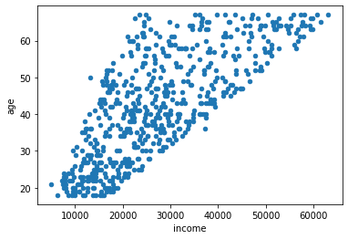

```python
bankdata_df.plot(x="income", y="age", kind="scatter")
```

*Both income and age are correlated and have a positive correlation*

**9. Create histograms for (non-normalized) Income (using 9 bins) and Age (using 15 bins).**

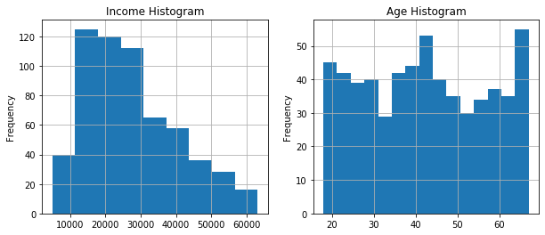

```python
temp1=bankdata_df["income"]
temp2=bankdata_df["age"]

fig = plt.figure(figsize=(10,4))
ax1 = fig.add_subplot(121)
ax1.set_title("Income Histogram")
temp1.plot(kind='hist', bins=9, grid=True)

ax1 = fig.add_subplot(122)
ax1.set_title("Age Histogram")
temp2.plot(kind='hist', bins=15, grid=True)
```

**10. Using a bargraph, plot the distribution of the values of the region attribute.**

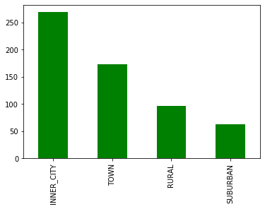

```python
bankdata_df['region'].value_counts().plot(kind='bar', color = 'green')
```

**11. Perform a cross-tabulation of the region attribute with the pep attribute. This requires the aggregation of the occurrences of each pep value (yes or no) separately for each value of the region attribute. Show the results as a 4 by 2 (region x pep) table with entries representing the counts. [Hint: you can either use Numpy or use aggregations fucntions in Pandas such as groupby() and cross-tab().] Then, either using Matplotlib directly or the plot() function in Pandas create a bar chart graph to visualize of the relationships between these sets of variables. [Hint: This example of creating simple bar charts using Matplotlib may be useful.]**

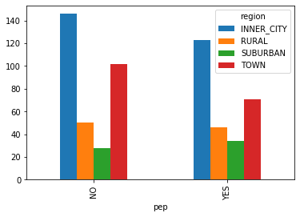

```python
gg = pd.crosstab(bankdata_df["pep"], bankdata_df["region"])
plt.show(gg.plot(kind="bar"))
```